# Assignment 1 Answers

**Question 1 [7 points]**  
i. Does Google have the right to look at your emails, documents, drawings or other objects?  
Yes [0.5 points]

2. Does Google have the right to use this information? What is meta-data? Can it collect meta-data about your information?
   - Yes [0.5 points]
   - Meta-data is data that describes other data [0.5 points]
   - Yes [0.5 points]
3. How can you turn on or off the geographical tracking mechanism associated with your account? + Sign in to google account -> Data & personalization tab -> Web & App activity -> See all Activity Controls -> Location History [1 point]
4. Are you satisfied with the level of security and user agreement with Google?
   - Opinion [4 points]

**Question 2 [3 points]**  
Does cloud computing reduce the overall cost for computers and computation for the “average” person? If so, how? Make reference to the definitions and components of cloud and traditional computing from the lecture notes. 4 or 5 sentences.

- Yes, cloud computing reduce the overall cost for computers and computation for the “average” person [1 point]
- Explanation. Must include definition or at least make distinction between the two paradigms. [2 points/1 point if missing]

**Question 3 [3 points]**  
Give an example of how concepts from computation drifted into the life sciences? 3 or 4 sentences.  
+ Good example [1.5 points]  
+ Explanation [1.5 points]

**Question 4 [3 points]**

Argue for and against each of the following items as a computing device (make references to the 3 fundamental properties of modern computers).

1. compass
2. a car
3. an assembly line to make cars at the Ford Inc. factory

Property 1: Input → algorithm → output  
Property 2: Notion of reprogrammability  
Property 3: Notion of state and memory

Argument for and against for each point worth 0.5 points or 1 point per item if going through three properties for item.

**Question 5 [4 points]**  
What privacy issues might arise in -omic studies? Are the issues of privacy more or less acute in a transcriptome-based study (as we saw in class) than say a genomic DNA-based study (sequencing the genome of individuals)? Remember that both studies are based on sequencing RNA and DNA of samples

Stating a valid privacy issue [2 points]  
Stating either genomic/transcriptomic issue with valid conceptual explanation [2 points]  
For example: Privacy regarding genomics is more of an issue because most peoples DNA is unique. Therefore, if someone has the DNA of a person, they have a unique identifier of that person, like taking someones fingerprints.

**Question 6 [4 points]**

[figure not shown]

Screenshot [2 points]

```r
# [2 points]
library("tidyverse")
## ── Attaching packages ───────────────────────────────────────────── tidyverse 1.3.0 ──
## ✓ ggplot2 3.3.2     ✓ purrr   0.3.4
## ✓ tibble  3.0.3     ✓ dplyr   1.0.1
## ✓ tidyr   1.1.1     ✓ stringr 1.4.0
## ✓ readr   1.3.1     ✓ forcats 0.5.0
## ── Conflicts ──────────────────────────────────────────────── tidyverse_conflicts() ──
## x dplyr::filter() masks stats::filter()
## x dplyr::lag()    masks stats::lag()
load("/cloud/project/data/small_brca.Rdata")
sessionInfo()
## R version 4.0.2 (2020-06-22)
## Platform: x86_64-pc-linux-gnu (64-bit)
## Running under: Ubuntu 16.04.6 LTS
##
## Matrix products: default
## BLAS:   /usr/lib/atlas-base/atlas/libblas.so.3.0
## LAPACK: /usr/lib/atlas-base/atlas/liblapack.so.3.0
##
## locale:
##  [1] LC_CTYPE=C.UTF-8       LC_NUMERIC=C           LC_TIME=C.UTF-8
##  [4] LC_COLLATE=C.UTF-8     LC_MONETARY=C.UTF-8    LC_MESSAGES=C.UTF-8
##  [7] LC_PAPER=C.UTF-8       LC_NAME=C              LC_ADDRESS=C
## [10] LC_TELEPHONE=C         LC_MEASUREMENT=C.UTF-8 LC_IDENTIFICATION=C
##
## attached base packages:
## [1] stats     graphics  grDevices utils     datasets  methods   base
##
## other attached packages:
## [1] forcats_0.5.0   stringr_1.4.0   dplyr_1.0.1     purrr_0.3.4
## [5] readr_1.3.1     tidyr_1.1.1     tibble_3.0.3    ggplot2_3.3.2
## [9] tidyverse_1.3.0
##
## loaded via a namespace (and not attached):
##  [1] Rcpp_1.0.5       cellranger_1.1.0 pillar_1.4.6     compiler_4.0.2
##  [5] dbplyr_1.4.4     tools_4.0.2      digest_0.6.25    lubridate_1.7.9
##  [9] jsonlite_1.7.0   evaluate_0.14    lifecycle_0.2.0  gtable_0.3.0
## [13] pkgconfig_2.0.3  rlang_0.4.7      reprex_0.3.0     cli_2.0.2
## [17] rstudioapi_0.11  DBI_1.1.0        yaml_2.2.1       haven_2.3.1
## [21] xfun_0.16        withr_2.2.0      xml2_1.3.2       httr_1.4.2
## [25] knitr_1.29       fs_1.5.0         hms_0.5.3        generics_0.0.2
## [29] vctrs_0.3.2      grid_4.0.2       tidyselect_1.1.0 glue_1.4.1
## [33] R6_2.4.1         fansi_0.4.1      readxl_1.3.1     rmarkdown_2.3
## [37] modelr_0.1.8     blob_1.2.1       magrittr_1.5     backports_1.1.8
## [41] scales_1.1.1     ellipsis_0.3.1   htmltools_0.5.0  rvest_0.3.6
## [45] assertthat_0.2.1 colorspace_1.4-1 stringi_1.4.6    munsell_0.5.0
## [49] broom_0.7.0      crayon_1.3.4
```

I will also accept, but I don’t like this as much

```r
date(); version
```

```
## [1] "Wed Sep 30 16:27:19 2020"
```

```
##                _
## platform       x86_64-pc-linux-gnu
## arch           x86_64
## os             linux-gnu
## system         x86_64, linux-gnu
## status
## major          4
## minor          0.2
## year           2020
## month          06
## day            22
## svn rev        78730
## language       R
## version.string R version 4.0.2 (2020-06-22)
## nickname       Taking Off Again
```

**Question 7 [5 points]**

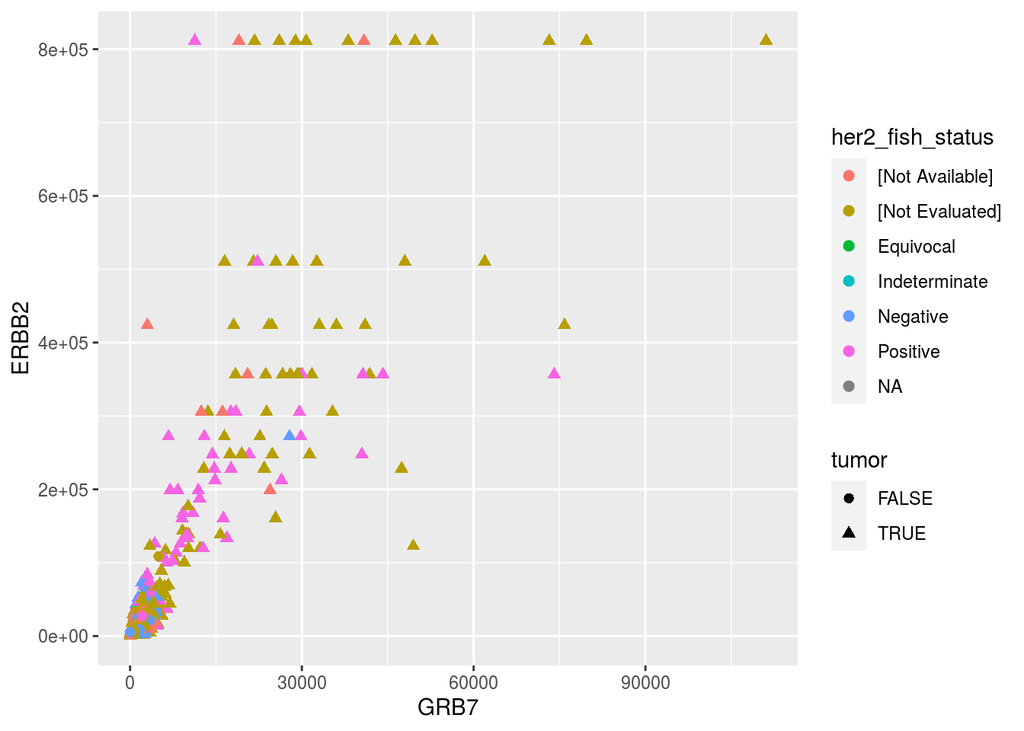

```r
# [2.5 points]

ggplot(data = small_brca) +
  geom_point(mapping = aes(x = GRB7,  y = ERBB2, color = her2_fish_status, shape = tumor), size = 2)
```

Valid interpretation of the data [2.5 points]

**Question 8 [5 points]**

Pie charts [1.5 points each]

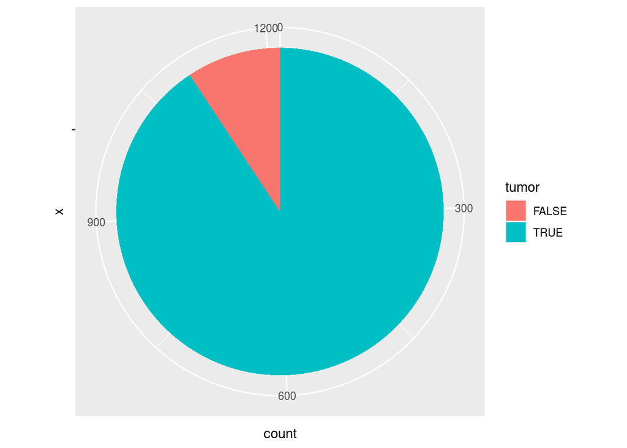

```r
ggplot (data = small_brca, mapping = aes (x = "", fill = tumor)) +
  geom_bar(width = 1) +
  coord_polar("y", start=0)
```

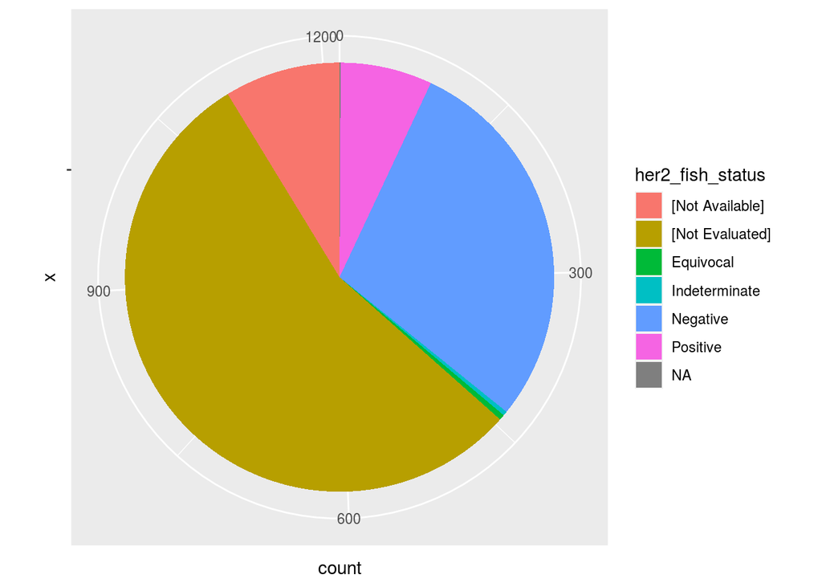

```r
ggplot (data = small_brca, mapping = aes (x = "", fill = her2_fish_status)) +
  geom_bar(width = 1) +
  coord_polar("y", start=0)
```

Valid interpretation of the data [2 points]

**Question 9 [5 points]**

Graph [2.5 points]

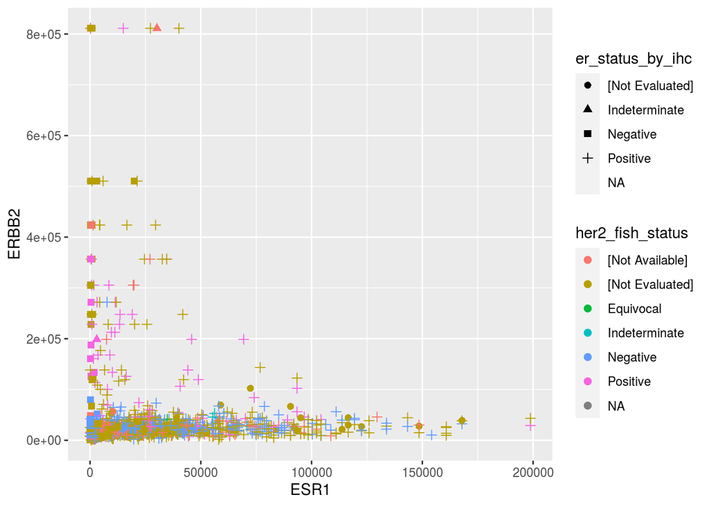

```r
ggplot(data = small_brca) +
  geom_point(mapping = aes(x = ESR1,  y = ERBB2, color = her2_fish_status, shape=er_status_by_ihc), size = 2)
## Warning: Removed 1 rows containing missing values (geom_point).
```

Valid interpretation of the data [2.5 points]

**Question 10 [5 points]**

Barplot [2.5 points]

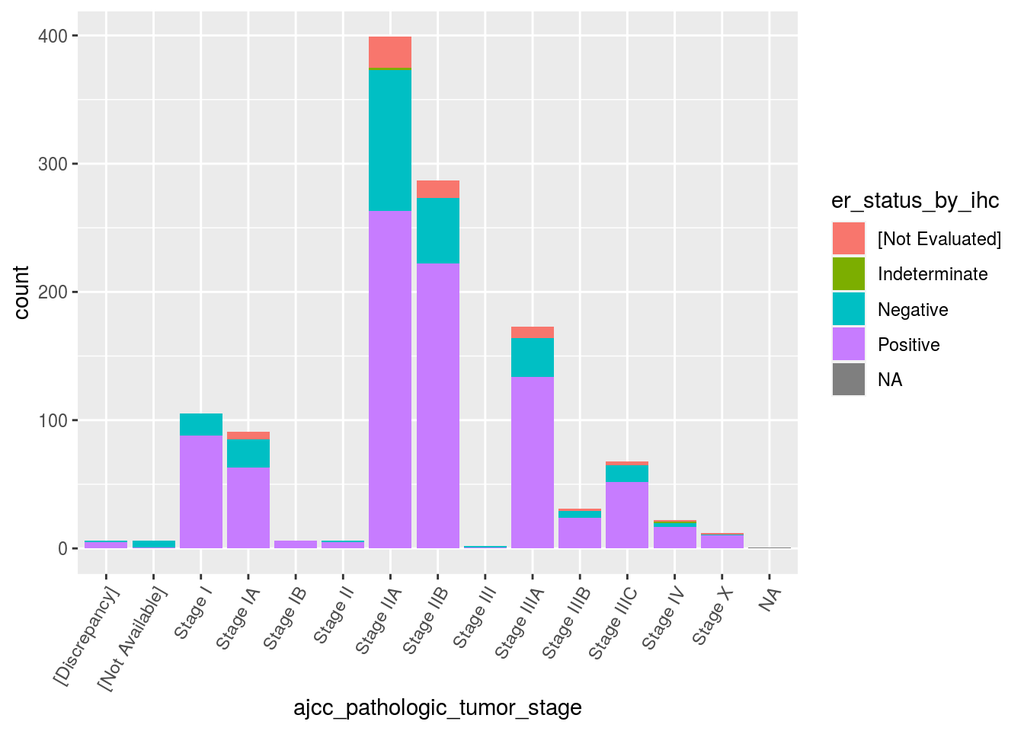

```r
ggplot(data = small_brca) +
  geom_bar(mapping = aes(x = ajcc_pathologic_tumor_stage, fill = er_status_by_ihc)) +
  theme(axis.text.x = element_text(angle = 60, hjust = 1))
```

Valid interpretation of the data [2.5 points]

**Question 11 [2 points]**

Assign logical variables

```r
c1 <- TRUE; c2 <- FALSE; c3 <- TRUE; wife <- TRUE; me <- FALSE
```

The condition is that at least one of Mike’s children at vegetables

```r
# [2 points]
(c1|c2|c3)
```

```
## [1] TRUE
```

**Question 12 [4 points]**

The logical expression is TRUE only when all of Mike’s children had vegetables and he and his wife are exhausted

```r
# [4 points]
((c1&c2&c3)&(me&wife))
```

```
## [1] FALSE
```